# Risk Factor Analysis

## Outcome Variable

**Outcome Variable:** stunted

## Predictor Variables

**Intervention Variable:** parity

**Adjustment Set:**

- arm
- W_mage
- meducyrs
- feducyrs
- hhwealth_quart
- W_mhtcm
- vagbrth
- W_nrooms
- impsan
- delta_W_mage
- delta_meducyrs
- delta_feducyrs
- delta_hhwealth_quart
- delta_W_mhtcm
- delta_vagbrth
- delta_W_nrooms
- delta_impsan

## Stratifying Variables

The analysis was stratified on these variable(s):

- agecat
- studyid
- country

## Data Summary

| agecat | studyid | country | parity | stunted | n_cell | n |
| --- | --- | --- | --- | --- | --- | --- |
| 6 months | ki1000304b-SAS-CompFeed | INDIA | 1 | 0 | 288 | 1336 |
| 6 months | ki1000304b-SAS-CompFeed | INDIA | 1 | 1 | 104 | 1336 |
| 6 months | ki1000304b-SAS-CompFeed | INDIA | 2 | 0 | 222 | 1336 |
| 6 months | ki1000304b-SAS-CompFeed | INDIA | 2 | 1 | 82 | 1336 |
| 6 months | ki1000304b-SAS-CompFeed | INDIA | 3+ | 0 | 446 | 1336 |
| 6 months | ki1000304b-SAS-CompFeed | INDIA | 3+ | 1 | 194 | 1336 |
| Birth | ki1000304b-SAS-CompFeed | INDIA | 1 | 0 | 34 | 187 |
| Birth | ki1000304b-SAS-CompFeed | INDIA | 1 | 1 | 13 | 187 |
| Birth | ki1000304b-SAS-CompFeed | INDIA | 2 | 0 | 37 | 187 |
| Birth | ki1000304b-SAS-CompFeed | INDIA | 2 | 1 | 16 | 187 |
| Birth | ki1000304b-SAS-CompFeed | INDIA | 3+ | 0 | 70 | 187 |
| Birth | ki1000304b-SAS-CompFeed | INDIA | 3+ | 1 | 17 | 187 |
| 6 months | ki1000304b-SAS-FoodSuppl | INDIA | 1 | 0 | 44 | 373 |
| 6 months | ki1000304b-SAS-FoodSuppl | INDIA | 1 | 1 | 28 | 373 |
| 6 months | ki1000304b-SAS-FoodSuppl | INDIA | 2 | 0 | 53 | 373 |
| 6 months | ki1000304b-SAS-FoodSuppl | INDIA | 2 | 1 | 31 | 373 |
| 6 months | ki1000304b-SAS-FoodSuppl | INDIA | 3+ | 0 | 118 | 373 |
| 6 months | ki1000304b-SAS-FoodSuppl | INDIA | 3+ | 1 | 99 | 373 |
| 6 months | ki1017093b-PROVIDE | BANGLADESH | 1 | 0 | 170 | 583 |
| 6 months | ki1017093b-PROVIDE | BANGLADESH | 1 | 1 | 41 | 583 |
| 6 months | ki1017093b-PROVIDE | BANGLADESH | 2 | 0 | 179 | 583 |
| 6 months | ki1017093b-PROVIDE | BANGLADESH | 2 | 1 | 33 | 583 |
| 6 months | ki1017093b-PROVIDE | BANGLADESH | 3+ | 0 | 140 | 583 |
| 6 months | ki1017093b-PROVIDE | BANGLADESH | 3+ | 1 | 20 | 583 |
| 24 months | ki1017093b-PROVIDE | BANGLADESH | 1 | 0 | 149 | 577 |
| 24 months | ki1017093b-PROVIDE | BANGLADESH | 1 | 1 | 62 | 577 |
| 24 months | ki1017093b-PROVIDE | BANGLADESH | 2 | 0 | 138 | 577 |
| 24 months | ki1017093b-PROVIDE | BANGLADESH | 2 | 1 | 75 | 577 |
| 24 months | ki1017093b-PROVIDE | BANGLADESH | 3+ | 0 | 100 | 577 |
| 24 months | ki1017093b-PROVIDE | BANGLADESH | 3+ | 1 | 53 | 577 |

[output cut: 132 more lines]

The following strata were considered:

- agecat: 24 months, studyid: ki1017093b-PROVIDE, country: BANGLADESH
- agecat: 24 months, studyid: ki1066203-TanzaniaChild2, country: TANZANIA, UNITED REPUBLIC OF
- agecat: 24 months, studyid: ki1101329-Keneba, country: GAMBIA
- agecat: 24 months, studyid: ki1113344-GMS-Nepal, country: NEPAL
- agecat: 24 months, studyid: ki1126311-ZVITAMBO, country: ZIMBABWE
- agecat: 24 months, studyid: ki1135781-COHORTS, country: GUATEMALA
- agecat: 24 months, studyid: ki1135781-COHORTS, country: INDIA
- agecat: 24 months, studyid: ki1135781-COHORTS, country: PHILIPPINES
- agecat: 24 months, studyid: kiGH5241-JiVitA-3, country: BANGLADESH
- agecat: 6 months, studyid: ki1000304b-SAS-CompFeed, country: INDIA
- agecat: 6 months, studyid: ki1000304b-SAS-FoodSuppl, country: INDIA
- agecat: 6 months, studyid: ki1017093b-PROVIDE, country: BANGLADESH
- agecat: 6 months, studyid: ki1066203-TanzaniaChild2, country: TANZANIA, UNITED REPUBLIC OF
- agecat: 6 months, studyid: ki1101329-Keneba, country: GAMBIA
- agecat: 6 months, studyid: ki1113344-GMS-Nepal, country: NEPAL
- agecat: 6 months, studyid: ki1126311-ZVITAMBO, country: ZIMBABWE
- agecat: 6 months, studyid: ki1135781-COHORTS, country: GUATEMALA
- agecat: 6 months, studyid: ki1135781-COHORTS, country: INDIA
- agecat: 6 months, studyid: ki1135781-COHORTS, country: PHILIPPINES
- agecat: 6 months, studyid: kiGH5241-JiVitA-3, country: BANGLADESH
- agecat: Birth, studyid: ki1000304b-SAS-CompFeed, country: INDIA
- agecat: Birth, studyid: ki1101329-Keneba, country: GAMBIA
- agecat: Birth, studyid: ki1126311-ZVITAMBO, country: ZIMBABWE
- agecat: Birth, studyid: ki1135781-COHORTS, country: GUATEMALA
- agecat: Birth, studyid: ki1135781-COHORTS, country: INDIA
- agecat: Birth, studyid: ki1135781-COHORTS, country: PHILIPPINES
- agecat: Birth, studyid: kiGH5241-JiVitA-3, country: BANGLADESH

### Dropped Strata

Some strata were dropped due to rare outcomes:

- agecat: 24 months, studyid: ki1066203-TanzaniaChild2, country: TANZANIA, UNITED REPUBLIC OF

## Methods Detail

We’re interested in the causal parameters $E[Y_a]$ for all values of $a \in \mathcal{A}$. These parameters represent the mean outcome if, possibly contrary to fact, we intervened to set all units to have $A=a$. Under the randomization and positivity assumptions, these are identified by the statistical parameters $\psi_a=E_W[E_{Y|A,W}(Y|A=a,W)]$. In addition, we’re interested in the mean of $Y$, $E[Y]$ under no intervention (the observed mean). We will estimate these parameters by using SuperLearner to fit the relevant likelihood factors – $E_{Y|A,W}(Y|A=a,W)$ and $p(A=a|W)$, and then updating our likelihood fit using a joint TMLE.

For unadjusted analyses ($W=\{\}$), initial likelihoods were estimated using Lrnr_glm to estimate the simple $E(Y|A)$ and Lrnr_mean to estimate $p(A)$. For adjusted analyses, a small library containing Lrnr_glmnet, Lrnr_xgboost, and Lrnr_mean was used.

Having estimated these parameters, we will then use the delta method to estimate relative risks and attributable risks relative to a prespecified baseline level of $A$.

# Results Detail

## Results Plots

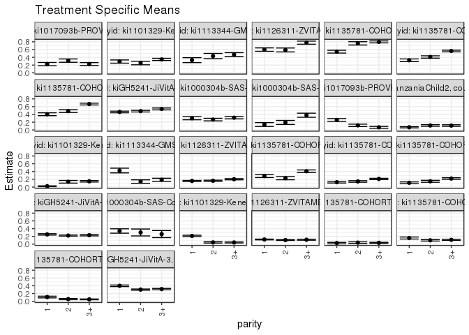

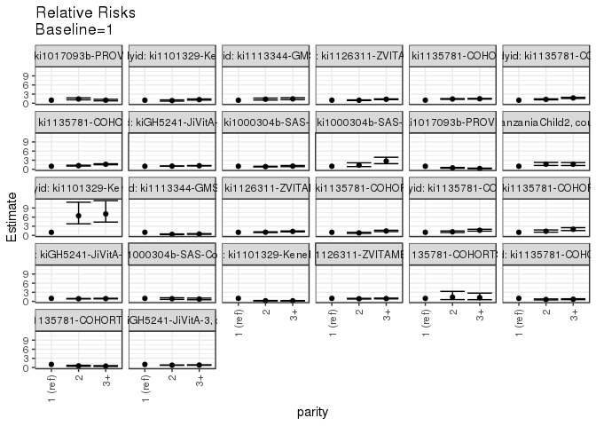

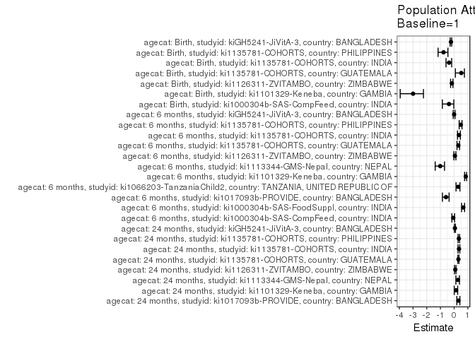

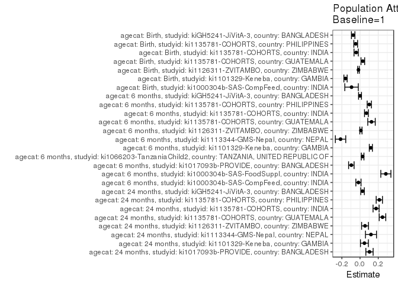

## Results Table

### Parameter: TSM

| agecat | studyid | country | intervention_level | baseline_level | estimate | ci_lower | ci_upper |
| --- | --- | --- | --- | --- | --- | --- | --- |
| Birth | ki1000304b-SAS-CompFeed | INDIA | 1 | NA | 0.3395080 | 0.2831392 | 0.3958768 |
| Birth | ki1000304b-SAS-CompFeed | INDIA | 2 | NA | 0.3014785 | 0.2122903 | 0.3906667 |
| Birth | ki1000304b-SAS-CompFeed | INDIA | 3+ | NA | 0.2594987 | 0.1678167 | 0.3511808 |
| Birth | ki1101329-Keneba | GAMBIA | 1 | NA | 0.2131847 | 0.1956294 | 0.2307401 |
| Birth | ki1101329-Keneba | GAMBIA | 2 | NA | 0.0455831 | 0.0290074 | 0.0621588 |
| Birth | ki1101329-Keneba | GAMBIA | 3+ | NA | 0.0442302 | 0.0319824 | 0.0564779 |
| Birth | ki1126311-ZVITAMBO | ZIMBABWE | 1 | NA | 0.1210004 | 0.1110111 | 0.1309897 |
| Birth | ki1126311-ZVITAMBO | ZIMBABWE | 2 | NA | 0.1059291 | 0.0949627 | 0.1168956 |
| Birth | ki1126311-ZVITAMBO | ZIMBABWE | 3+ | NA | 0.1147885 | 0.1025187 | 0.1270583 |
| Birth | ki1135781-COHORTS | GUATEMALA | 1 | NA | 0.0280375 | 0.0087664 | 0.0473087 |
| Birth | ki1135781-COHORTS | GUATEMALA | 2 | NA | 0.0392726 | 0.0178537 | 0.0606916 |
| Birth | ki1135781-COHORTS | GUATEMALA | 3+ | NA | 0.0347932 | 0.0217608 | 0.0478255 |
| Birth | ki1135781-COHORTS | INDIA | 1 | NA | 0.1580446 | 0.1326078 | 0.1834813 |
| Birth | ki1135781-COHORTS | INDIA | 2 | NA | 0.0995419 | 0.0803894 | 0.1186945 |
| Birth | ki1135781-COHORTS | INDIA | 3+ | NA | 0.1121472 | 0.0992782 | 0.1250162 |
| Birth | ki1135781-COHORTS | PHILIPPINES | 1 | NA | 0.1089796 | 0.0868537 | 0.1311054 |
| Birth | ki1135781-COHORTS | PHILIPPINES | 2 | NA | 0.0562455 | 0.0411506 | 0.0713404 |
| Birth | ki1135781-COHORTS | PHILIPPINES | 3+ | NA | 0.0493531 | 0.0397709 | 0.0589353 |
| Birth | kiGH5241-JiVitA-3 | BANGLADESH | 1 | NA | 0.3989361 | 0.3784590 | 0.4194131 |
| Birth | kiGH5241-JiVitA-3 | BANGLADESH | 2 | NA | 0.3013506 | 0.2867141 | 0.3159871 |
| Birth | kiGH5241-JiVitA-3 | BANGLADESH | 3+ | NA | 0.3141654 | 0.2968105 | 0.3315203 |
| 6 months | ki1000304b-SAS-CompFeed | INDIA | 1 | NA | 0.3021017 | 0.2623015 | 0.3419019 |
| 6 months | ki1000304b-SAS-CompFeed | INDIA | 2 | NA | 0.2664873 | 0.2334367 | 0.2995379 |
| 6 months | ki1000304b-SAS-CompFeed | INDIA | 3+ | NA | 0.3155956 | 0.2852178 | 0.3459735 |
| 6 months | ki1000304b-SAS-FoodSuppl | INDIA | 1 | NA | 0.1397408 | 0.0905787 | 0.1889029 |
| 6 months | ki1000304b-SAS-FoodSuppl | INDIA | 2 | NA | 0.1933983 | 0.1412673 | 0.2455294 |
| 6 months | ki1000304b-SAS-FoodSuppl | INDIA | 3+ | NA | 0.3793236 | 0.3263769 | 0.4322704 |
| 6 months | ki1017093b-PROVIDE | BANGLADESH | 1 | NA | 0.2570373 | 0.2211945 | 0.2928800 |
| 6 months | ki1017093b-PROVIDE | BANGLADESH | 2 | NA | 0.1185280 | 0.0883082 | 0.1487478 |
| 6 months | ki1017093b-PROVIDE | BANGLADESH | 3+ | NA | 0.0681687 | 0.0443000 | 0.0920374 |
| 6 months | ki1066203-TanzaniaChild2 | TANZANIA, UNITED REPUBLIC OF | 1 | NA | 0.0681586 | 0.0523697 | 0.0839476 |
| 6 months | ki1066203-TanzaniaChild2 | TANZANIA, UNITED REPUBLIC OF | 2 | NA | 0.1151796 | 0.0945595 | 0.1357997 |
| 6 months | ki1066203-TanzaniaChild2 | TANZANIA, UNITED REPUBLIC OF | 3+ | NA | 0.1129281 | 0.0925904 | 0.1332659 |
| 6 months | ki1101329-Keneba | GAMBIA | 1 | NA | 0.0210562 | 0.0112772 | 0.0308351 |
| 6 months | ki1101329-Keneba | GAMBIA | 2 | NA | 0.1355045 | 0.1016927 | 0.1693163 |
| 6 months | ki1101329-Keneba | GAMBIA | 3+ | NA | 0.1486106 | 0.1293986 | 0.1678226 |
| 6 months | ki1113344-GMS-Nepal | NEPAL | 1 | NA | 0.4259383 | 0.3649838 | 0.4868928 |
| 6 months | ki1113344-GMS-Nepal | NEPAL | 2 | NA | 0.1416566 | 0.0968996 | 0.1864135 |
| 6 months | ki1113344-GMS-Nepal | NEPAL | 3+ | NA | 0.1877095 | 0.1486542 | 0.2267648 |
| 6 months | ki1126311-ZVITAMBO | ZIMBABWE | 1 | NA | 0.1567765 | 0.1429592 | 0.1705938 |
| 6 months | ki1126311-ZVITAMBO | ZIMBABWE | 2 | NA | 0.1619729 | 0.1469905 | 0.1769553 |
| 6 months | ki1126311-ZVITAMBO | ZIMBABWE | 3+ | NA | 0.2017107 | 0.1855393 | 0.2178822 |
| 6 months | ki1135781-COHORTS | GUATEMALA | 1 | NA | 0.2840245 | 0.2450204 | 0.3230285 |
| 6 months | ki1135781-COHORTS | GUATEMALA | 2 | NA | 0.2288442 | 0.1883656 | 0.2693227 |
| 6 months | ki1135781-COHORTS | GUATEMALA | 3+ | NA | 0.4077112 | 0.3746808 | 0.4407416 |
| 6 months | ki1135781-COHORTS | INDIA | 1 | NA | 0.1256866 | 0.1040141 | 0.1473590 |
| 6 months | ki1135781-COHORTS | INDIA | 2 | NA | 0.1450672 | 0.1245619 | 0.1655724 |
| 6 months | ki1135781-COHORTS | INDIA | 3+ | NA | 0.2095625 | 0.1934785 | 0.2256465 |
| 6 months | ki1135781-COHORTS | PHILIPPINES | 1 | NA | 0.1095340 | 0.0862435 | 0.1328245 |
| 6 months | ki1135781-COHORTS | PHILIPPINES | 2 | NA | 0.1483444 | 0.1232980 | 0.1733907 |
| 6 months | ki1135781-COHORTS | PHILIPPINES | 3+ | NA | 0.2192465 | 0.1989938 | 0.2394992 |
| 6 months | kiGH5241-JiVitA-3 | BANGLADESH | 1 | NA | 0.2517013 | 0.2341111 | 0.2692915 |
| 6 months | kiGH5241-JiVitA-3 | BANGLADESH | 2 | NA | 0.2223571 | 0.2093245 | 0.2353896 |
| 6 months | kiGH5241-JiVitA-3 | BANGLADESH | 3+ | NA | 0.2317066 | 0.2136007 | 0.2498126 |
| 24 months | ki1017093b-PROVIDE | BANGLADESH | 1 | NA | 0.2254438 | 0.1836287 | 0.2672588 |
| 24 months | ki1017093b-PROVIDE | BANGLADESH | 2 | NA | 0.3149591 | 0.2723679 | 0.3575502 |
| 24 months | ki1017093b-PROVIDE | BANGLADESH | 3+ | NA | 0.2266816 | 0.1892708 | 0.2640923 |
| 24 months | ki1101329-Keneba | GAMBIA | 1 | NA | 0.2906759 | 0.2493935 | 0.3319583 |
| 24 months | ki1101329-Keneba | GAMBIA | 2 | NA | 0.2527227 | 0.2070729 | 0.2983726 |
| 24 months | ki1101329-Keneba | GAMBIA | 3+ | NA | 0.3454241 | 0.3177363 | 0.3731119 |
| 24 months | ki1113344-GMS-Nepal | NEPAL | 1 | NA | 0.3266971 | 0.2640188 | 0.3893753 |
| 24 months | ki1113344-GMS-Nepal | NEPAL | 2 | NA | 0.4324880 | 0.3647944 | 0.5001815 |
| 24 months | ki1113344-GMS-Nepal | NEPAL | 3+ | NA | 0.4699419 | 0.4198596 | 0.5200242 |
| 24 months | ki1126311-ZVITAMBO | ZIMBABWE | 1 | NA | 0.5987364 | 0.5544163 | 0.6430565 |
| 24 months | ki1126311-ZVITAMBO | ZIMBABWE | 2 | NA | 0.5890573 | 0.5384120 | 0.6397025 |
| 24 months | ki1126311-ZVITAMBO | ZIMBABWE | 3+ | NA | 0.7771914 | 0.7369029 | 0.8174799 |
| 24 months | ki1135781-COHORTS | GUATEMALA | 1 | NA | 0.5451080 | 0.5088711 | 0.5813448 |
| 24 months | ki1135781-COHORTS | GUATEMALA | 2 | NA | 0.7595651 | 0.7173581 | 0.8017720 |
| 24 months | ki1135781-COHORTS | GUATEMALA | 3+ | NA | 0.7973213 | 0.7713991 | 0.8232435 |
| 24 months | ki1135781-COHORTS | INDIA | 1 | NA | 0.3237253 | 0.2890831 | 0.3583675 |
| 24 months | ki1135781-COHORTS | INDIA | 2 | NA | 0.4088855 | 0.3788677 | 0.4389033 |
| 24 months | ki1135781-COHORTS | INDIA | 3+ | NA | 0.5625145 | 0.5411394 | 0.5838896 |
| 24 months | ki1135781-COHORTS | PHILIPPINES | 1 | NA | 0.4046473 | 0.3678945 | 0.4414000 |
| 24 months | ki1135781-COHORTS | PHILIPPINES | 2 | NA | 0.4848485 | 0.4498904 | 0.5198067 |
| 24 months | ki1135781-COHORTS | PHILIPPINES | 3+ | NA | 0.6665921 | 0.6436584 | 0.6895258 |
| 24 months | kiGH5241-JiVitA-3 | BANGLADESH | 1 | NA | 0.4632724 | 0.4422683 | 0.4842765 |
| 24 months | kiGH5241-JiVitA-3 | BANGLADESH | 2 | NA | 0.4844049 | 0.4631224 | 0.5056873 |
| 24 months | kiGH5241-JiVitA-3 | BANGLADESH | 3+ | NA | 0.5413216 | 0.5169540 | 0.5656892 |

### Parameter: E(Y)

| agecat | studyid | country | intervention_level | baseline_level | estimate | ci_lower | ci_upper |
| --- | --- | --- | --- | --- | --- | --- | --- |
| Birth | ki1000304b-SAS-CompFeed | INDIA | NA | NA | 0.2459893 | 0.1594019 | 0.3325767 |
| Birth | ki1101329-Keneba | GAMBIA | NA | NA | 0.0533049 | 0.0415628 | 0.0650470 |
| Birth | ki1126311-ZVITAMBO | ZIMBABWE | NA | NA | 0.1035505 | 0.0984723 | 0.1086287 |
| Birth | ki1135781-COHORTS | GUATEMALA | NA | NA | 0.0586854 | 0.0428942 | 0.0744767 |
| Birth | ki1135781-COHORTS | INDIA | NA | NA | 0.1152353 | 0.1054865 | 0.1249842 |
| Birth | ki1135781-COHORTS | PHILIPPINES | NA | NA | 0.0613115 | 0.0527962 | 0.0698268 |
| Birth | kiGH5241-JiVitA-3 | BANGLADESH | NA | NA | 0.3232622 | 0.3156056 | 0.3309189 |
| 6 months | ki1000304b-SAS-CompFeed | INDIA | NA | NA | 0.2844311 | 0.2666491 | 0.3022132 |
| 6 months | ki1000304b-SAS-FoodSuppl | INDIA | NA | NA | 0.4235925 | 0.3733796 | 0.4738054 |
| 6 months | ki1017093b-PROVIDE | BANGLADESH | NA | NA | 0.1612350 | 0.1313580 | 0.1911120 |
| 6 months | ki1066203-TanzaniaChild2 | TANZANIA, UNITED REPUBLIC OF | NA | NA | 0.0965000 | 0.0835560 | 0.1094440 |
| 6 months | ki1101329-Keneba | GAMBIA | NA | NA | 0.1398644 | 0.1229849 | 0.1567440 |
| 6 months | ki1113344-GMS-Nepal | NEPAL | NA | NA | 0.2113677 | 0.1776128 | 0.2451225 |
| 6 months | ki1126311-ZVITAMBO | ZIMBABWE | NA | NA | 0.1662648 | 0.1582516 | 0.1742780 |
| 6 months | ki1135781-COHORTS | GUATEMALA | NA | NA | 0.4099896 | 0.3788775 | 0.4411017 |
| 6 months | ki1135781-COHORTS | INDIA | NA | NA | 0.1957586 | 0.1838852 | 0.2076319 |
| 6 months | ki1135781-COHORTS | PHILIPPINES | NA | NA | 0.2112260 | 0.1958496 | 0.2266024 |
| 6 months | kiGH5241-JiVitA-3 | BANGLADESH | NA | NA | 0.2513837 | 0.2432545 | 0.2595129 |
| 24 months | ki1017093b-PROVIDE | BANGLADESH | NA | NA | 0.3292894 | 0.2909105 | 0.3676684 |
| 24 months | ki1101329-Keneba | GAMBIA | NA | NA | 0.3386628 | 0.3136483 | 0.3636773 |
| 24 months | ki1113344-GMS-Nepal | NEPAL | NA | NA | 0.4468938 | 0.4032281 | 0.4905594 |
| 24 months | ki1126311-ZVITAMBO | ZIMBABWE | NA | NA | 0.6535088 | 0.6097853 | 0.6972322 |
| 24 months | ki1135781-COHORTS | GUATEMALA | NA | NA | 0.7919400 | 0.7675726 | 0.8163075 |
| 24 months | ki1135781-COHORTS | INDIA | NA | NA | 0.5001478 | 0.4832966 | 0.5169990 |
| 24 months | ki1135781-COHORTS | PHILIPPINES | NA | NA | 0.6167689 | 0.5974942 | 0.6360437 |
| 24 months | kiGH5241-JiVitA-3 | BANGLADESH | NA | NA | 0.4908395 | 0.4777071 | 0.5039719 |

### Parameter: RR

| agecat | studyid | country | intervention_level | baseline_level | estimate | ci_lower | ci_upper |
| --- | --- | --- | --- | --- | --- | --- | --- |
| Birth | ki1000304b-SAS-CompFeed | INDIA | 1 | 1 | 1.0000000 | 1.0000000 | 1.0000000 |
| Birth | ki1000304b-SAS-CompFeed | INDIA | 2 | 1 | 0.8879865 | 0.6615175 | 1.1919866 |
| Birth | ki1000304b-SAS-CompFeed | INDIA | 3+ | 1 | 0.7643377 | 0.5356938 | 1.0905708 |
| Birth | ki1101329-Keneba | GAMBIA | 1 | 1 | 1.0000000 | 1.0000000 | 1.0000000 |
| Birth | ki1101329-Keneba | GAMBIA | 2 | 1 | 0.2138196 | 0.1471443 | 0.3107073 |
| Birth | ki1101329-Keneba | GAMBIA | 3+ | 1 | 0.2074734 | 0.1555839 | 0.2766687 |
| Birth | ki1126311-ZVITAMBO | ZIMBABWE | 1 | 1 | 1.0000000 | 1.0000000 | 1.0000000 |
| Birth | ki1126311-ZVITAMBO | ZIMBABWE | 2 | 1 | 0.8754447 | 0.7670655 | 0.9991370 |
| Birth | ki1126311-ZVITAMBO | ZIMBABWE | 3+ | 1 | 0.9486624 | 0.8289394 | 1.0856769 |
| Birth | ki1135781-COHORTS | GUATEMALA | 1 | 1 | 1.0000000 | 1.0000000 | 1.0000000 |
| Birth | ki1135781-COHORTS | GUATEMALA | 2 | 1 | 1.4007158 | 0.5943790 | 3.3009321 |
| Birth | ki1135781-COHORTS | GUATEMALA | 3+ | 1 | 1.2409491 | 0.5647561 | 2.7267604 |
| Birth | ki1135781-COHORTS | INDIA | 1 | 1 | 1.0000000 | 1.0000000 | 1.0000000 |
| Birth | ki1135781-COHORTS | INDIA | 2 | 1 | 0.6298346 | 0.4902329 | 0.8091900 |
| Birth | ki1135781-COHORTS | INDIA | 3+ | 1 | 0.7095921 | 0.5824937 | 0.8644230 |
| Birth | ki1135781-COHORTS | PHILIPPINES | 1 | 1 | 1.0000000 | 1.0000000 | 1.0000000 |
| Birth | ki1135781-COHORTS | PHILIPPINES | 2 | 1 | 0.5161106 | 0.3690640 | 0.7217453 |
| Birth | ki1135781-COHORTS | PHILIPPINES | 3+ | 1 | 0.4528656 | 0.3430438 | 0.5978456 |
| Birth | kiGH5241-JiVitA-3 | BANGLADESH | 1 | 1 | 1.0000000 | 1.0000000 | 1.0000000 |
| Birth | kiGH5241-JiVitA-3 | BANGLADESH | 2 | 1 | 0.7553857 | 0.7044720 | 0.8099790 |
| Birth | kiGH5241-JiVitA-3 | BANGLADESH | 3+ | 1 | 0.7875081 | 0.7313658 | 0.8479600 |
| 6 months | ki1000304b-SAS-CompFeed | INDIA | 1 | 1 | 1.0000000 | 1.0000000 | 1.0000000 |
| 6 months | ki1000304b-SAS-CompFeed | INDIA | 2 | 1 | 0.8821110 | 0.7740195 | 1.0052975 |
| 6 months | ki1000304b-SAS-CompFeed | INDIA | 3+ | 1 | 1.0446668 | 0.8748745 | 1.2474117 |
| 6 months | ki1000304b-SAS-FoodSuppl | INDIA | 1 | 1 | 1.0000000 | 1.0000000 | 1.0000000 |
| 6 months | ki1000304b-SAS-FoodSuppl | INDIA | 2 | 1 | 1.3839792 | 0.8966376 | 2.1362014 |
| 6 months | ki1000304b-SAS-FoodSuppl | INDIA | 3+ | 1 | 2.7144804 | 1.8547803 | 3.9726559 |
| 6 months | ki1017093b-PROVIDE | BANGLADESH | 1 | 1 | 1.0000000 | 1.0000000 | 1.0000000 |
| 6 months | ki1017093b-PROVIDE | BANGLADESH | 2 | 1 | 0.4611316 | 0.3477027 | 0.6115637 |
| 6 months | ki1017093b-PROVIDE | BANGLADESH | 3+ | 1 | 0.2652095 | 0.1836213 | 0.3830497 |
| 6 months | ki1066203-TanzaniaChild2 | TANZANIA, UNITED REPUBLIC OF | 1 | 1 | 1.0000000 | 1.0000000 | 1.0000000 |
| 6 months | ki1066203-TanzaniaChild2 | TANZANIA, UNITED REPUBLIC OF | 2 | 1 | 1.6898756 | 1.2625209 | 2.2618870 |
| 6 months | ki1066203-TanzaniaChild2 | TANZANIA, UNITED REPUBLIC OF | 3+ | 1 | 1.6568430 | 1.2372671 | 2.2187034 |
| 6 months | ki1101329-Keneba | GAMBIA | 1 | 1 | 1.0000000 | 1.0000000 | 1.0000000 |
| 6 months | ki1101329-Keneba | GAMBIA | 2 | 1 | 6.4353853 | 3.7974245 | 10.9058610 |
| 6 months | ki1101329-Keneba | GAMBIA | 3+ | 1 | 7.0578192 | 4.3631056 | 11.4168247 |
| 6 months | ki1113344-GMS-Nepal | NEPAL | 1 | 1 | 1.0000000 | 1.0000000 | 1.0000000 |
| 6 months | ki1113344-GMS-Nepal | NEPAL | 2 | 1 | 0.3325753 | 0.2344481 | 0.4717732 |
| 6 months | ki1113344-GMS-Nepal | NEPAL | 3+ | 1 | 0.4406964 | 0.3431147 | 0.5660305 |
| 6 months | ki1126311-ZVITAMBO | ZIMBABWE | 1 | 1 | 1.0000000 | 1.0000000 | 1.0000000 |
| 6 months | ki1126311-ZVITAMBO | ZIMBABWE | 2 | 1 | 1.0331452 | 0.9098006 | 1.1732122 |
| 6 months | ki1126311-ZVITAMBO | ZIMBABWE | 3+ | 1 | 1.2866135 | 1.1427852 | 1.4485436 |
| 6 months | ki1135781-COHORTS | GUATEMALA | 1 | 1 | 1.0000000 | 1.0000000 | 1.0000000 |
| 6 months | ki1135781-COHORTS | GUATEMALA | 2 | 1 | 0.8057199 | 0.6486817 | 1.0007752 |
| 6 months | ki1135781-COHORTS | GUATEMALA | 3+ | 1 | 1.4354791 | 1.2286452 | 1.6771320 |
| 6 months | ki1135781-COHORTS | INDIA | 1 | 1 | 1.0000000 | 1.0000000 | 1.0000000 |
| 6 months | ki1135781-COHORTS | INDIA | 2 | 1 | 1.1541979 | 0.9245511 | 1.4408860 |
| 6 months | ki1135781-COHORTS | INDIA | 3+ | 1 | 1.6673418 | 1.3812707 | 2.0126602 |
| 6 months | ki1135781-COHORTS | PHILIPPINES | 1 | 1 | 1.0000000 | 1.0000000 | 1.0000000 |
| 6 months | ki1135781-COHORTS | PHILIPPINES | 2 | 1 | 1.3543224 | 1.0342864 | 1.7733861 |
| 6 months | ki1135781-COHORTS | PHILIPPINES | 3+ | 1 | 2.0016296 | 1.5878716 | 2.5232022 |
| 6 months | kiGH5241-JiVitA-3 | BANGLADESH | 1 | 1 | 1.0000000 | 1.0000000 | 1.0000000 |
| 6 months | kiGH5241-JiVitA-3 | BANGLADESH | 2 | 1 | 0.8834163 | 0.8063738 | 0.9678197 |
| 6 months | kiGH5241-JiVitA-3 | BANGLADESH | 3+ | 1 | 0.9205619 | 0.8336537 | 1.0165303 |
| 24 months | ki1017093b-PROVIDE | BANGLADESH | 1 | 1 | 1.0000000 | 1.0000000 | 1.0000000 |
| 24 months | ki1017093b-PROVIDE | BANGLADESH | 2 | 1 | 1.3970626 | 1.1163236 | 1.7484033 |
| 24 months | ki1017093b-PROVIDE | BANGLADESH | 3+ | 1 | 1.0054905 | 0.7863479 | 1.2857045 |
| 24 months | ki1101329-Keneba | GAMBIA | 1 | 1 | 1.0000000 | 1.0000000 | 1.0000000 |
| 24 months | ki1101329-Keneba | GAMBIA | 2 | 1 | 0.8694314 | 0.6920810 | 1.0922290 |
| 24 months | ki1101329-Keneba | GAMBIA | 3+ | 1 | 1.1883482 | 1.0115444 | 1.3960548 |
| 24 months | ki1113344-GMS-Nepal | NEPAL | 1 | 1 | 1.0000000 | 1.0000000 | 1.0000000 |
| 24 months | ki1113344-GMS-Nepal | NEPAL | 2 | 1 | 1.3238194 | 1.0358986 | 1.6917659 |
| 24 months | ki1113344-GMS-Nepal | NEPAL | 3+ | 1 | 1.4384636 | 1.1568825 | 1.7885807 |
| 24 months | ki1126311-ZVITAMBO | ZIMBABWE | 1 | 1 | 1.0000000 | 1.0000000 | 1.0000000 |
| 24 months | ki1126311-ZVITAMBO | ZIMBABWE | 2 | 1 | 0.9838340 | 0.8824859 | 1.0968214 |
| 24 months | ki1126311-ZVITAMBO | ZIMBABWE | 3+ | 1 | 1.2980527 | 1.1902017 | 1.4156766 |
| 24 months | ki1135781-COHORTS | GUATEMALA | 1 | 1 | 1.0000000 | 1.0000000 | 1.0000000 |
| 24 months | ki1135781-COHORTS | GUATEMALA | 2 | 1 | 1.3934213 | 1.2805390 | 1.5162544 |
| 24 months | ki1135781-COHORTS | GUATEMALA | 3+ | 1 | 1.4626851 | 1.3616889 | 1.5711722 |
| 24 months | ki1135781-COHORTS | INDIA | 1 | 1 | 1.0000000 | 1.0000000 | 1.0000000 |
| 24 months | ki1135781-COHORTS | INDIA | 2 | 1 | 1.2630633 | 1.1115226 | 1.4352645 |
| 24 months | ki1135781-COHORTS | INDIA | 3+ | 1 | 1.7376291 | 1.5528844 | 1.9443528 |
| 24 months | ki1135781-COHORTS | PHILIPPINES | 1 | 1 | 1.0000000 | 1.0000000 | 1.0000000 |
| 24 months | ki1135781-COHORTS | PHILIPPINES | 2 | 1 | 1.1982005 | 1.0702567 | 1.3414393 |
| 24 months | ki1135781-COHORTS | PHILIPPINES | 3+ | 1 | 1.6473412 | 1.4965474 | 1.8133291 |
| 24 months | kiGH5241-JiVitA-3 | BANGLADESH | 1 | 1 | 1.0000000 | 1.0000000 | 1.0000000 |
| 24 months | kiGH5241-JiVitA-3 | BANGLADESH | 2 | 1 | 1.0456157 | 0.9841699 | 1.1108977 |
| 24 months | kiGH5241-JiVitA-3 | BANGLADESH | 3+ | 1 | 1.1684737 | 1.0987639 | 1.2426061 |

### Parameter: PAR

| agecat | studyid | country | intervention_level | baseline_level | estimate | ci_lower | ci_upper |
| --- | --- | --- | --- | --- | --- | --- | --- |
| Birth | ki1000304b-SAS-CompFeed | INDIA | 1 | NA | -0.0935187 | -0.1677853 | -0.0192520 |
| Birth | ki1101329-Keneba | GAMBIA | 1 | NA | -0.1598798 | -0.1778194 | -0.1419402 |
| Birth | ki1126311-ZVITAMBO | ZIMBABWE | 1 | NA | -0.0174499 | -0.0263013 | -0.0085984 |
| Birth | ki1135781-COHORTS | GUATEMALA | 1 | NA | 0.0306479 | 0.0105072 | 0.0507886 |
| Birth | ki1135781-COHORTS | INDIA | 1 | NA | -0.0428092 | -0.0663159 | -0.0193025 |
| Birth | ki1135781-COHORTS | PHILIPPINES | 1 | NA | -0.0476681 | -0.0683457 | -0.0269905 |
| Birth | kiGH5241-JiVitA-3 | BANGLADESH | 1 | NA | -0.0756738 | -0.0948153 | -0.0565324 |
| 6 months | ki1000304b-SAS-CompFeed | INDIA | 1 | NA | -0.0176706 | -0.0460696 | 0.0107283 |
| 6 months | ki1000304b-SAS-FoodSuppl | INDIA | 1 | NA | 0.2838517 | 0.2283472 | 0.3393562 |
| 6 months | ki1017093b-PROVIDE | BANGLADESH | 1 | NA | -0.0958023 | -0.1259806 | -0.0656240 |
| 6 months | ki1066203-TanzaniaChild2 | TANZANIA, UNITED REPUBLIC OF | 1 | NA | 0.0283414 | 0.0138370 | 0.0428458 |
| 6 months | ki1101329-Keneba | GAMBIA | 1 | NA | 0.1188083 | 0.1017408 | 0.1358757 |
| 6 months | ki1113344-GMS-Nepal | NEPAL | 1 | NA | -0.2145706 | -0.2717329 | -0.1574084 |
| 6 months | ki1126311-ZVITAMBO | ZIMBABWE | 1 | NA | 0.0094883 | -0.0027598 | 0.0217363 |
| 6 months | ki1135781-COHORTS | GUATEMALA | 1 | NA | 0.1259651 | 0.0847912 | 0.1671391 |
| 6 months | ki1135781-COHORTS | INDIA | 1 | NA | 0.0700720 | 0.0489957 | 0.0911483 |
| 6 months | ki1135781-COHORTS | PHILIPPINES | 1 | NA | 0.1016920 | 0.0783944 | 0.1249896 |
| 6 months | kiGH5241-JiVitA-3 | BANGLADESH | 1 | NA | -0.0003176 | -0.0164670 | 0.0158317 |
| 24 months | ki1017093b-PROVIDE | BANGLADESH | 1 | NA | 0.1038457 | 0.0638055 | 0.1438858 |
| 24 months | ki1101329-Keneba | GAMBIA | 1 | NA | 0.0479869 | 0.0044562 | 0.0915177 |
| 24 months | ki1113344-GMS-Nepal | NEPAL | 1 | NA | 0.1201967 | 0.0594038 | 0.1809896 |
| 24 months | ki1126311-ZVITAMBO | ZIMBABWE | 1 | NA | 0.0547724 | 0.0171243 | 0.0924204 |
| 24 months | ki1135781-COHORTS | GUATEMALA | 1 | NA | 0.2468320 | 0.2107452 | 0.2829189 |
| 24 months | ki1135781-COHORTS | INDIA | 1 | NA | 0.1764225 | 0.1431566 | 0.2096884 |
| 24 months | ki1135781-COHORTS | PHILIPPINES | 1 | NA | 0.2121217 | 0.1775516 | 0.2466918 |
| 24 months | kiGH5241-JiVitA-3 | BANGLADESH | 1 | NA | 0.0275671 | 0.0081289 | 0.0470054 |

### Parameter: PAF

| agecat | studyid | country | intervention_level | baseline_level | estimate | ci_lower | ci_upper |
| --- | --- | --- | --- | --- | --- | --- | --- |
| Birth | ki1000304b-SAS-CompFeed | INDIA | 1 | NA | -0.3801736 | -0.8620809 | -0.0229842 |
| Birth | ki1101329-Keneba | GAMBIA | 1 | NA | -2.9993454 | -3.9370971 | -2.2397101 |
| Birth | ki1126311-ZVITAMBO | ZIMBABWE | 1 | NA | -0.1685155 | -0.2580559 | -0.0853481 |
| Birth | ki1135781-COHORTS | GUATEMALA | 1 | NA | 0.5222403 | 0.0907487 | 0.7489646 |
| Birth | ki1135781-COHORTS | INDIA | 1 | NA | -0.3714941 | -0.5942747 | -0.1798445 |
| Birth | ki1135781-COHORTS | PHILIPPINES | 1 | NA | -0.7774743 | -1.1730713 | -0.4538938 |
| Birth | kiGH5241-JiVitA-3 | BANGLADESH | 1 | NA | -0.2340943 | -0.2951357 | -0.1759299 |
| 6 months | ki1000304b-SAS-CompFeed | INDIA | 1 | NA | -0.0621261 | -0.1649336 | 0.0316084 |
| 6 months | ki1000304b-SAS-FoodSuppl | INDIA | 1 | NA | 0.6701056 | 0.5428434 | 0.7619408 |
| 6 months | ki1017093b-PROVIDE | BANGLADESH | 1 | NA | -0.5941779 | -0.8565809 | -0.3688620 |
| 6 months | ki1066203-TanzaniaChild2 | TANZANIA, UNITED REPUBLIC OF | 1 | NA | 0.2936932 | 0.1367459 | 0.4221061 |
| 6 months | ki1101329-Keneba | GAMBIA | 1 | NA | 0.8494531 | 0.7645659 | 0.9037337 |
| 6 months | ki1113344-GMS-Nepal | NEPAL | 1 | NA | -1.0151535 | -1.3847038 | -0.7028713 |
| 6 months | ki1126311-ZVITAMBO | ZIMBABWE | 1 | NA | 0.0570673 | -0.0192544 | 0.1276740 |
| 6 months | ki1135781-COHORTS | GUATEMALA | 1 | NA | 0.3072398 | 0.2083689 | 0.3937622 |
| 6 months | ki1135781-COHORTS | INDIA | 1 | NA | 0.3579511 | 0.2441060 | 0.4546501 |
| 6 months | ki1135781-COHORTS | PHILIPPINES | 1 | NA | 0.4814369 | 0.3661401 | 0.5757617 |
| 6 months | kiGH5241-JiVitA-3 | BANGLADESH | 1 | NA | -0.0012636 | -0.0676139 | 0.0609632 |
| 24 months | ki1017093b-PROVIDE | BANGLADESH | 1 | NA | 0.3153629 | 0.1951014 | 0.4176558 |
| 24 months | ki1101329-Keneba | GAMBIA | 1 | NA | 0.1416953 | 0.0071453 | 0.2580114 |
| 24 months | ki1113344-GMS-Nepal | NEPAL | 1 | NA | 0.2689603 | 0.1264932 | 0.3881913 |
| 24 months | ki1126311-ZVITAMBO | ZIMBABWE | 1 | NA | 0.0838128 | 0.0265766 | 0.1376835 |
| 24 months | ki1135781-COHORTS | GUATEMALA | 1 | NA | 0.3116802 | 0.2669426 | 0.3536876 |
| 24 months | ki1135781-COHORTS | INDIA | 1 | NA | 0.3527407 | 0.2837593 | 0.4150786 |
| 24 months | ki1135781-COHORTS | PHILIPPINES | 1 | NA | 0.3439240 | 0.2861880 | 0.3969902 |
| 24 months | kiGH5241-JiVitA-3 | BANGLADESH | 1 | NA | 0.0561633 | 0.0160249 | 0.0946642 |